# PA1_Template

ACBLimehouse

6/4/2017

# R Markdown and Data Setup

## Initial Setup

### Data Download and Import

In downloading data, I try to use a standard code sequence. In order to do so, I set up the code block to use the data objects below.  
I also take this opportunity to set up the libraries I plan to use in analysis.

```r
DataURL <- "https://d396qusza40orc.cloudfront.net/repdata%2Fdata%2Factivity.zip"
File.Name <- "Activity monitoring data.zip"
Data.file <- "activity.csv"
Data.Name <- "Activity.Data"
ColumnNames <- c("steps", "date", "interval")
setwd(Local.Directory)
library(dtplyr)
library(ggplot2)
```

### Get the Data

```r
if (!file.exists(File.Name)){
  download.file(DataURL, File.Name, method="curl")
}
if (!file.exists(Data.file)) {
  unzip(File.Name)
}
```

### Load & Process the Data

Loading and processing the data is relatively simple in this case. The main processing steps are:

1. transforming the “date” variable from a string into an R date format; and,
2. turning the “interval” variable into a factor.

```r
if (!exists(Data.Name)){
  Activity.Data <- (
      read.csv(file = Data.file, header = TRUE, sep = ",",
                na.strings = "NA", col.names = ColumnNames))
  Activity.Data$date <- as.Date(Activity.Data$date,format("%Y-%m-%d"))
  Activity.Data$interval <- as.factor(Activity.Data$interval)
}
```

# Data Analysis

We need to check to ensure the data is cleaned and ready for analysis.  
A good method is the str() function.

```r
str(Activity.Data)
```

```
## 'data.frame':    17568 obs. of  3 variables:
##  $ steps   : int  NA NA NA NA NA NA NA NA NA NA ...
##  $ date    : Date, format: "2012-10-01" "2012-10-01" ...
##  $ interval: Factor w/ 288 levels "0","5","10","15",..: 1 2 3 4 5 6 7 8 9 10 ...
```

## What is mean total number of steps taken per day?

For this part of the assignment, you can ignore the missing values in the dataset.

- Calculate the total number of steps taken per day.

```r
Steps.per.day <- aggregate(steps ~ date, Activity.Data, sum)
colnames(Steps.per.day) <- c("date", "steps")
head(Steps.per.day)
```

```
##         date steps
## 1 2012-10-02   126
## 2 2012-10-03 11352
## 3 2012-10-04 12116
## 4 2012-10-05 13294
## 5 2012-10-06 15420
## 6 2012-10-07 11015
```

- Make a histogram of the total number of steps taken each day

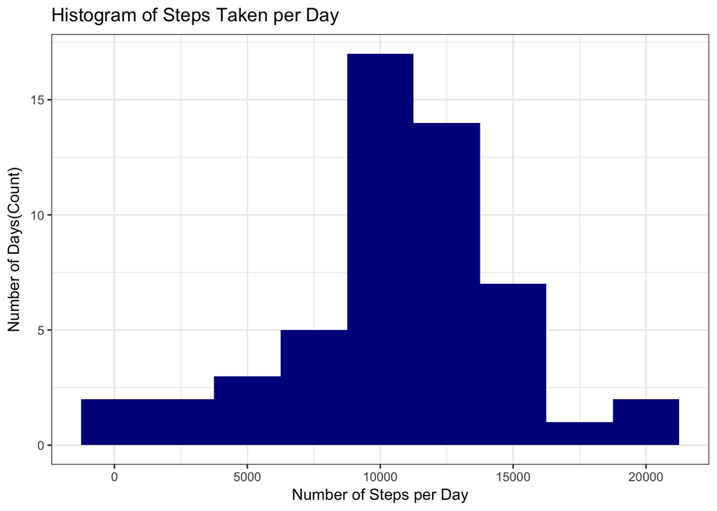

```r
ggplot(Steps.per.day, aes(x = steps)) +
       geom_histogram(fill = "dark blue", binwidth = 2500) +
       labs(title="Histogram of Steps Taken per Day",
       x = "Number of Steps per Day", y = "Number of Days(Count)") +
       theme_bw()
```

Next, we calculate and report the mean and median of the total number of steps taken per day.

```r
MeanSteps <- mean(Steps.per.day$steps, na.rm = TRUE)
MedianSteps <- median(Steps.per.day$steps, na.rm = TRUE)
```

The values are:

- Mean steps per day: 10766.2.
- Median steps per day is 10765.

## What is the average daily activity pattern?

### Make a time series plot (i.e. 𝚝𝚢𝚙𝚎 = “𝚕”) of the 5-minute interval (x-axis) and the average number of steps taken, averaged across all days (y-axis).

First we calculate the average number of steps per interval.

```r
steps.per.interval <- aggregate(Activity.Data$steps,
                                by = list(interval = Activity.Data$interval),
                                FUN=mean, na.rm=TRUE)
#convert to integers
##this helps in plotting
steps.per.interval$interval <-
        as.integer(levels(steps.per.interval$interval)[steps.per.interval$interval])
colnames(steps.per.interval) <- c("interval", "steps")
```

Then, we create the plot.

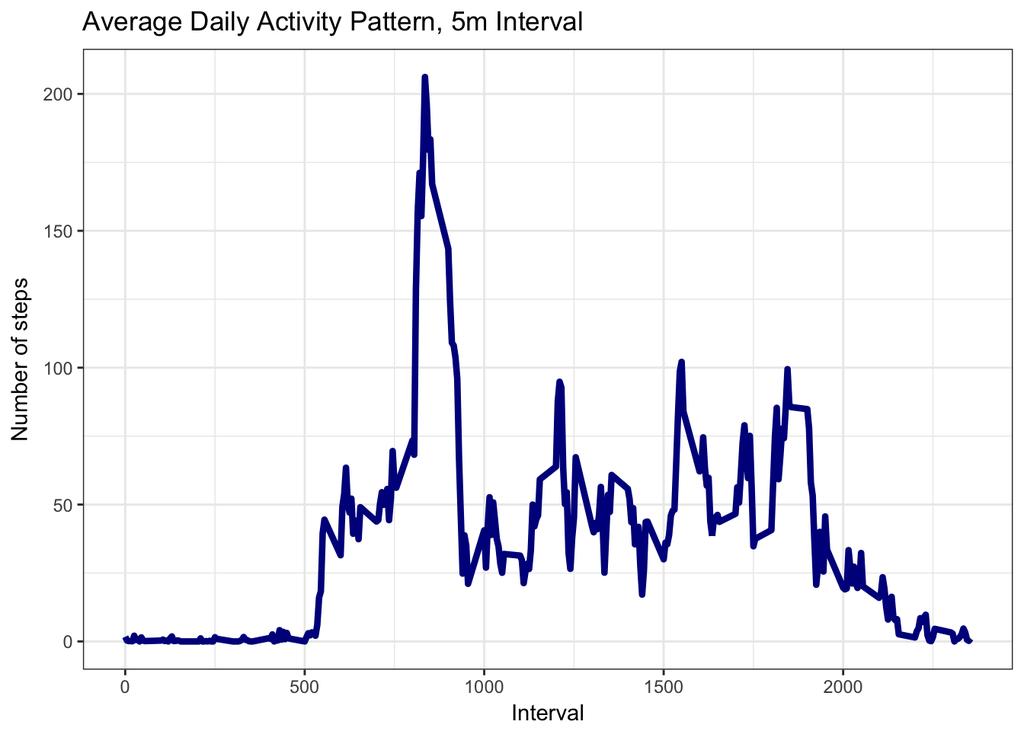

```r
ggplot(steps.per.interval, aes(x=interval, y=steps)) +
        geom_line(color="dark blue", size=1.5) +
        labs(title="Average Daily Activity Pattern, 5m Interval",
        x="Interval", y="Number of steps") +
        theme_bw()
```

### Which 5-minute interval, on average across all the days in the dataset, contains the maximum number of steps?

```r
MaxInterval <- steps.per.interval[which.max(steps.per.interval$steps),]
```

The 835 interval is the highest with 206 steps.

## Imputing missing values

Note that there are a number of days/intervals where there are missing values (coded as.𝙽𝙰). The presence of missing days may introduce bias into some calculations or summaries of the data.

### Calculate and report the total number of missing values in the dataset (i.e. the total number of rows with 𝙽𝙰s)

We use is.na() to calculate the total number of missing values in Activity.Data$steps.

```r
missingsteps <- sum(is.na(Activity.Data$steps))
```

There are 2304 missing values in Activity.Data$steps.

### Devise a strategy for filling in all of the missing values in the dataset.

```r
# Find the NA positions
na_pos <- which(is.na(Activity.Data$steps))

# Create a vector of means
mean_vec <- rep(mean(Activity.Data$steps, na.rm=TRUE), times=length(na_pos))
```

### Create a new dataset with missing values imputed.

Next, we apply that mean to the missing values in that position using the vector of positions na_pos created above.

```r
activity <- Activity.Data
activity[na_pos, "steps"] <- mean_vec
```

Finally, we check to make sure there are no remaining missing values and then display the first few rows of the new dataset.

```r
sum(is.na(activity$steps))
```

```
## [1] 0
```

```r
head(activity)
```

```
##     steps       date interval
## 1 37.3826 2012-10-01        0
## 2 37.3826 2012-10-01        5
## 3 37.3826 2012-10-01       10
## 4 37.3826 2012-10-01       15
## 5 37.3826 2012-10-01       20
## 6 37.3826 2012-10-01       25
```

### Make a histogram of the total number of steps taken each day and Calculate and report the mean and median total number of steps taken per day.

Aggregate and plot the data once more - this time in red.

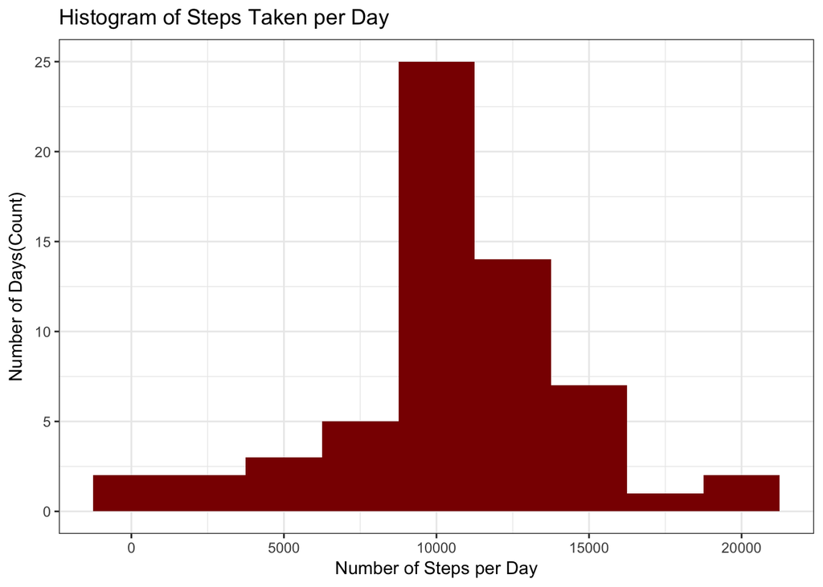

```r
Steps.per.day2 <- aggregate(steps ~ date, activity, sum)
colnames(Steps.per.day2) <- c("date", "steps")

## Plotting the Histogram comes next
ggplot(Steps.per.day2, aes(x = steps)) +
       geom_histogram(fill = "dark red", binwidth = 2500) +
       labs(title="Histogram of Steps Taken per Day",
       x = "Number of Steps per Day", y = "Number of Days(Count)") +
       theme_bw()
```

Next, calculate the Mean and Median again.

```r
MeanSteps2 <- mean(Steps.per.day2$steps, na.rm = TRUE)
MedianSteps2 <- median(Steps.per.day2$steps, na.rm = TRUE)
```

The **former** values were:

- Mean steps per day: 10766.2.
- Median steps per 10765.

The **new** values, post imputation:

- Mean steps per day: 10766.2.
- Median steps per day: 10766.2.

#### Do these values differ from the estimates from the first part of the assignment?

Unsurprisingly, the mean did not change as we used it to impute values at the interval level. However, the median increased.

#### What is the impact of imputing missing data on the estimates of the total daily number of steps?

The impact of imputing missing data was to increase the number of days with 10K or more steps.

## Are there differences in activity patterns between weekdays and weekends?

Use the dataset with the filled-in missing values for this part.

### Create a new factor variable in the dataset with two levels – “weekday” and “weekend” indicating whether a given date is a weekday or weekend day.

First, we use two functions in sequence to compute the weekdays from the date attribute, calculate the mean steps by interval, and then apply the functions to our imputed data.

```r
weekdays_steps <- function(data) {
    weekdays_steps <- aggregate(data$steps, by=list(interval = data$interval),
                          FUN=mean, na.rm=T)
    # convert to integers for plotting
    weekdays_steps$interval <-
            as.integer(levels(weekdays_steps$interval)[weekdays_steps$interval])
    colnames(weekdays_steps) <- c("interval", "steps")
    weekdays_steps
}

data_by_weekdays <- function(data) {
    data$weekday <-
            as.factor(weekdays(data$date)) # weekdays
    weekend_data <- subset(data, weekday %in% c("Saturday","Sunday"))
    weekday_data <- subset(data, !weekday %in% c("Saturday","Sunday"))

    weekend_steps <- weekdays_steps(weekend_data)
    weekday_steps <- weekdays_steps(weekday_data)

    weekend_steps$dayofweek <- rep("weekend", nrow(weekend_steps))
    weekday_steps$dayofweek <- rep("weekday", nrow(weekday_steps))

    data_by_weekdays <- rbind(weekend_steps, weekday_steps)
    data_by_weekdays$dayofweek <- as.factor(data_by_weekdays$dayofweek)
    data_by_weekdays
}

data_weekdays <- data_by_weekdays(activity)
```

### Make a panel plot containing a time series plot (i.e. 𝚝𝚢𝚙𝚎 = “𝚕”) of the 5-minute interval (x-axis) and the average number of steps taken, averaged across all weekday days or weekend days (y-axis).

For the last question, we take the aggregated activity data and plot it.

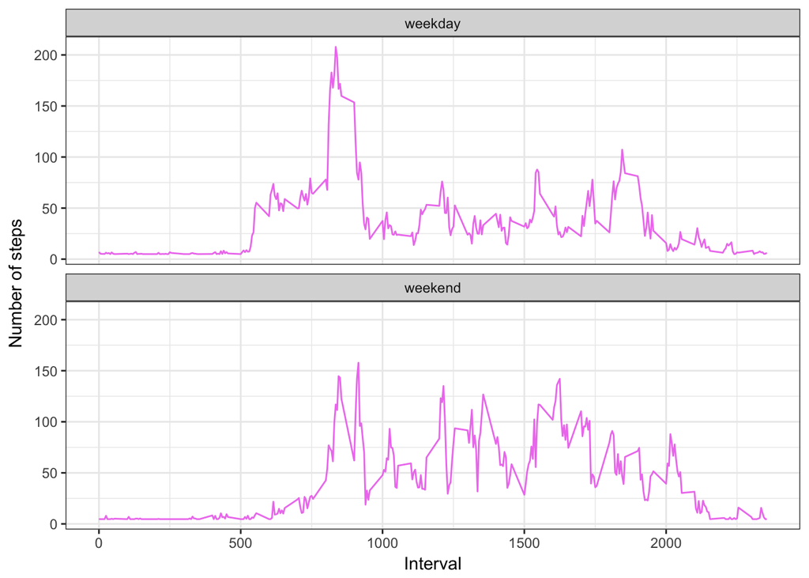

```r
ggplot(data_weekdays, aes(x=interval, y=steps)) +
        geom_line(color="violet") +
        facet_wrap(~ dayofweek, nrow=2, ncol=1) +
        labs(x="Interval", y="Number of steps") +
        theme_bw()
```

## Workspace Cleanup

As a last step, I always remove any data or values remaining in the global environment.

```r
rm(list = ls())
```